# Vyprávíme příběh s daty

## Vizualizace dat

## Matplotlib, Seaborn 🐟

### Nasťa a Filip Sedlákovi

## Proč budeme používat dvě knihovny pro vizualizaci dat?

`Matplotlib` je základní knihovna v Pythonu pro vrsvenou vizualizaci dat

[`Seaborn`](https://seaborn.pydata.org/tutorial.html) doplňuje [`Matplotlib`](https://matplotlib.org/tutorials/index.html) a děla grafy hezčí ❤️

Náš postup: udělat základ v `matplotlibu` a případně ho doplnit `seabornem`

## Vizualizace dat - postup

1. Vytvořit obrázek
2. Přidat data - přímky, body, sloupce, atd.
3. Přidat popisky os, celého obrázku, text do grafu

## Jak naimportuji matplotlib a seaborn?

```python
import matplotlib.pyplot as plt
import seaborn as sns

# Následujicí řádek je potřeba pro zobrazení matplotlib grafů v Jupyter notebooku
%matplotlib inline
```

## Odbočka: jak naimportuji vzorová data z knihovny seaborn?

`sns.load_dataset('jméno souboru bez koncovky')`

Seznam dostupných dat [zde](https://github.com/mwaskom/seaborn-data).

**Pozor**: pro načtení svých dat použijte `pd.read_csv`.

```python
cars = sns.load_dataset('car_crashes')
cars.head()
```

|  | total | speeding | alcohol | not_distracted | no_previous | ins_premium | ins_losses | abbrev |
| --- | --- | --- | --- | --- | --- | --- | --- | --- |
| 0 | 18.8 | 7.332 | 5.640 | 18.048 | 15.040 | 784.55 | 145.08 | AL |
| 1 | 18.1 | 7.421 | 4.525 | 16.290 | 17.014 | 1053.48 | 133.93 | AK |
| 2 | 18.6 | 6.510 | 5.208 | 15.624 | 17.856 | 899.47 | 110.35 | AZ |
| 3 | 22.4 | 4.032 | 5.824 | 21.056 | 21.280 | 827.34 | 142.39 | AR |
| 4 | 12.0 | 4.200 | 3.360 | 10.920 | 10.680 | 878.41 | 165.63 | CA |

## První příklad

Použijeme data `primates.csv` a uděláme bodový graf, kde na x ose bude váha mozku a na y ose vaha těla.

Pro vykreslení bodového grafu použíjeme [matplotlib.pyplot.scatter](https://matplotlib.org/api/_as_gen/matplotlib.pyplot.scatter.html)

```python
import pandas as pd

data = pd.read_csv('primates.csv')
data.rename(index=str, columns={'Unnamed: 0': 'Species'}, inplace=True)
data
```

|  | Species | Bodywt | Brainwt |
| --- | --- | --- | --- |
| 0 | Potar monkey | 10.0 | 115 |
| 1 | Gorilla | 207.0 | 406 |
| 2 | Human | 62.0 | 1320 |
| 3 | Rhesus monkey | 6.8 | 179 |
| 4 | Chimp | 52.2 | 440 |

## Vytvořit obrázek

[`plt.subplots`](https://matplotlib.org/api/_as_gen/matplotlib.pyplot.subplots.html) vytvoří obrázek s grafy (základní nastavení 1 graf)

Můžeme změnit velikost pomocí `figsize`

`Figure` je celý obrázek

`Axes` je graf (může být i více), **neplést s axis (osa)**

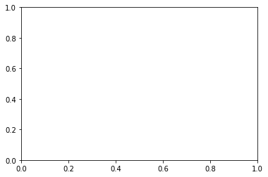

```python
fig, ax = plt.subplots()
```

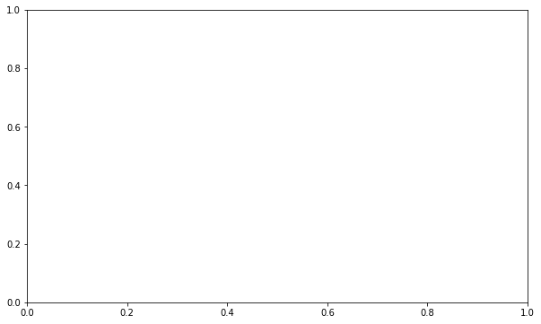

```python
fig, ax = plt.subplots(figsize=(10,6))
```

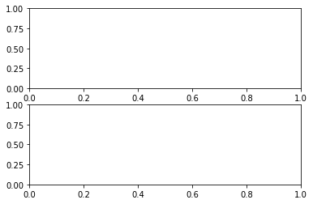

```python
fig, ax = plt.subplots(2)
```

## Přidat data

[`ax.scatter`](https://matplotlib.org/api/_as_gen/matplotlib.pyplot.scatter.html?highlight=scatter#matplotlib.pyplot.scatter) vytvoří bodový graf

```python
fig, ax = plt.subplots(figsize=(10,6))
ax.scatter(x='Brainwt', y='Bodywt', data=data)
```

[output not shown]

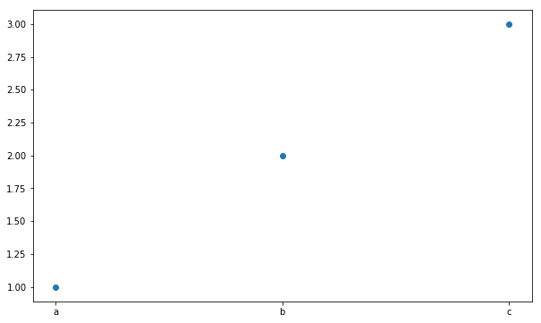

```python
# Do x a y můžeme dávat i seznamy hodnot
fig, ax = plt.subplots(figsize=(10,6))
ax.scatter(x=['a', 'b', 'c'], y=[1,2,3])
```

```python
fig, ax = plt.subplots(figsize=(10,6))
ax.scatter(x=data.Brainwt, y=data.Bodywt)
```

[output not shown]

```python
fig, ax = plt.subplots(figsize=(10,6))
ax.scatter(x=data.Brainwt, y=data.Bodywt)
# show() nás zbaví <matplotlib.collections.PathCollection at 0x...>
# Navíc tento kód zobrazí graf i kdybychom jej spouštěli mimo Jupyter
plt.show()
```

[output not shown]

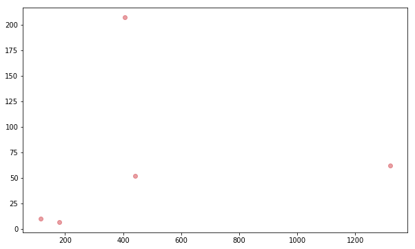

```python
# Můžeme nastavit barvu a průhlednost
fig, ax = plt.subplots(figsize=(10,6))
ax.scatter(x='Brainwt', y='Bodywt', data=data, c='#d24049', alpha=0.5)
plt.show()
```

## Parametry `scatter` (platí nejen pro tuto metodu)

- `c` - barva, např. 'g', '#d24049', 'red' i seznam barev
- `alpha` - průhlednost, 0 (uplně průhledné) - 1 (neprůhledné)
- `marker` - tvar bodu, více [tady](https://matplotlib.org/api/markers_api.html?highlight=marker#module-matplotlib.markers)
- `s` - velikost i seznam velikostí

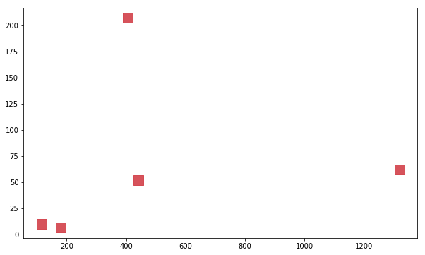

```python
# Pomoci marker a s nastavime symbol a jeho velikost
fig, ax = plt.subplots(figsize=(10,6))
ax.scatter(x='Brainwt', y='Bodywt', data=data, c='#d24049', alpha=0.9, marker='s', s=200)
plt.show()
```

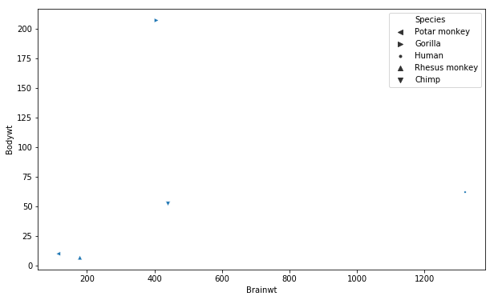

```python
# Pomoci marker a s nastavime symbol a jeho velikost
fig, ax = plt.subplots(figsize=(10,6))
sns.scatterplot(data=data, x="Brainwt", y="Bodywt", style="Species",
                markers=["<", ">", ".", "^", "v"])
plt.show()
```

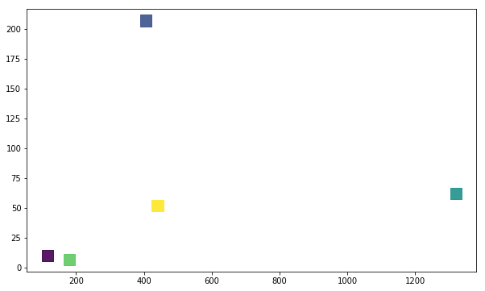

```python
fig, ax = plt.subplots(figsize=(10,6))
ax.scatter(
    x='Brainwt', y='Bodywt', data=data,
    c=[1, 2, 3, 4, 5], alpha=0.9, marker='s', s=200
)
plt.show()
```

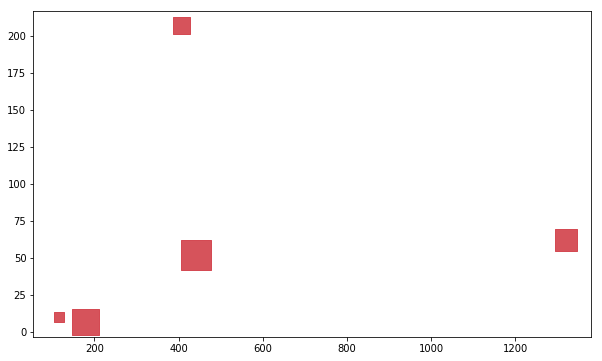

```python
fig, ax = plt.subplots(figsize=(10,6))
ax.scatter(
    x='Brainwt', y='Bodywt', data=data,
    c='#d24049', alpha=0.9, marker='s', s=[100, 300, 500, 700, 900]
)
plt.show()
```